# porject 1 . Clustering San Francisco Police Department Incidents_Application1

```python
from google.colab import drive
drive.mount('/content/drive')
```

```python
import folium
```

```python
folium.__version__
```

[output not shown]

```python
!pip install folium==0.5.0
```

[output not shown]

```python
folium.__version__
```

```
'0.5.0'
```

```python
import pandas as pd
```

```python
dataset = pd.read_csv('/Police_Department_Incidents_-_Previous_Year__2016_.csv')
```

```python
dataset.head()
```

|  | IncidntNum | Category | Descript | DayOfWeek | Date | Time | PdDistrict | Resolution | Address | X | Y | Location | PdId |
| --- | --- | --- | --- | --- | --- | --- | --- | --- | --- | --- | --- | --- | --- |
| 0 | 120058272 | WEAPON LAWS | POSS OF PROHIBITED WEAPON | Friday | 01/29/2016 12:00:00 AM | 11:00 | SOUTHERN | ARREST, BOOKED | 800 Block of BRYANT ST | -122.403405 | 37.775421 | (37.775420706711, -122.403404791479) | 12005827212120 |
| 1 | 120058272 | WEAPON LAWS | FIREARM, LOADED, IN VEHICLE, POSSESSION OR USE | Friday | 01/29/2016 12:00:00 AM | 11:00 | SOUTHERN | ARREST, BOOKED | 800 Block of BRYANT ST | -122.403405 | 37.775421 | (37.775420706711, -122.403404791479) | 12005827212168 |
| 2 | 141059263 | WARRANTS | WARRANT ARREST | Monday | 04/25/2016 12:00:00 AM | 14:59 | BAYVIEW | ARREST, BOOKED | KEITH ST / SHAFTER AV | -122.388856 | 37.729981 | (37.7299809672996, -122.388856204292) | 14105926363010 |
| 3 | 160013662 | NON-CRIMINAL | LOST PROPERTY | Tuesday | 01/05/2016 12:00:00 AM | 23:50 | TENDERLOIN | NONE | JONES ST / OFARRELL ST | -122.412971 | 37.785788 | (37.7857883766888, -122.412970537591) | 16001366271000 |
| 4 | 160002740 | NON-CRIMINAL | LOST PROPERTY | Friday | 01/01/2016 12:00:00 AM | 00:30 | MISSION | NONE | 16TH ST / MISSION ST | -122.419672 | 37.765050 | (37.7650501214668, -122.419671780296) | 16000274071000 |

```python
dataset.shape
```

```
(150500, 13)
```

```python
limit = 100
```

```python
dataset=dataset.iloc[0:limit , : ]
```

```python
dataset.shape
```

```
(100, 13)
```

```python
dataset.describe()
```

|  | IncidntNum | X | Y | PdId |
| --- | --- | --- | --- | --- |
| count | 1.000000e+02 | 100.000000 | 100.000000 | 1.000000e+02 |
| mean | 1.578879e+08 | -122.420689 | 37.761941 | 1.578879e+13 |
| std | 7.303656e+06 | 0.024520 | 0.024102 | 7.303656e+11 |
| min | 1.200583e+08 | -122.507750 | 37.709201 | 1.200583e+13 |
| 25% | 1.600058e+08 | -122.426449 | 37.742323 | 1.600058e+13 |
| 50% | 1.600115e+08 | -122.414542 | 37.768030 | 1.600115e+13 |
| 75% | 1.600137e+08 | -122.403848 | 37.782048 | 1.600137e+13 |
| max | 1.601892e+08 | -122.376758 | 37.800457 | 1.601892e+13 |

```python
dataset.info()
```

```
<class 'pandas.core.frame.DataFrame'>
RangeIndex: 100 entries, 0 to 99
Data columns (total 13 columns):
 #   Column      Non-Null Count  Dtype
---  ------      --------------  -----
 0   IncidntNum  100 non-null    int64
 1   Category    100 non-null    object
 2   Descript    100 non-null    object
 3   DayOfWeek   100 non-null    object
 4   Date        100 non-null    object
 5   Time        100 non-null    object
 6   PdDistrict  100 non-null    object
 7   Resolution  100 non-null    object
 8   Address     100 non-null    object
 9   X           100 non-null    float64
 10  Y           100 non-null    float64
 11  Location    100 non-null    object
 12  PdId        100 non-null    int64
dtypes: float64(2), int64(2), object(9)
memory usage: 10.3+ KB
```

```python
dataset.describe(include='O')
```

|  | Category | Descript | DayOfWeek | Date | Time | PdDistrict | Resolution | Address | Location |
| --- | --- | --- | --- | --- | --- | --- | --- | --- | --- |
| count | 100 | 100 | 100 | 100 | 100 | 100 | 100 | 100 | 100 |
| unique | 20 | 62 | 7 | 16 | 81 | 10 | 4 | 82 | 84 |
| top | OTHER OFFENSES | DRIVERS LICENSE, SUSPENDED OR REVOKED | Tuesday | 01/05/2016 12:00:00 AM | 23:15 | SOUTHERN | NONE | 3RD ST / EGBERT AV | (37.775420706711, -122.403404791479) |
| freq | 21 | 8 | 40 | 34 | 3 | 20 | 58 | 3 | 3 |

```python
folium.Map()
```

Make this Notebook Trusted to load map: File -> Trust Notebook

[interactive chart not shown]

```python
us_map = folium.Map(location=[37.0902,-95.7129] , zoom_start=4)
us_map
```

Make this Notebook Trusted to load map: File -> Trust Notebook

[interactive chart not shown]

```python
us_map = folium.Map(location=[37.0902,-95.7129] , zoom_start=4 , tiles='stamen toner')
us_map
```

Make this Notebook Trusted to load map: File -> Trust Notebook

[interactive chart not shown]

```python
us_map = folium.Map(location=[37.0902,-95.7129] , zoom_start=4 , tiles='stamen terrain')
us_map
```

Make this Notebook Trusted to load map: File -> Trust Notebook

[interactive chart not shown]

```python
latitude = 37.7749
longitude = -122.4194
```

```python
sanfran_map = folium.Map(location=[latitude ,longitude] ,zoom_start=12 ,tiles = 'stamen terrain')
```

```python
sanfran_map
```

Make this Notebook Trusted to load map: File -> Trust Notebook

[interactive chart not shown]

```python
incidents = folium.map.FeatureGroup()
for lat , lng in zip(dataset['Y'] , dataset['X']):
  incidents.add_child(
      folium.features.CircleMarker(
          [lat , lng],
          redius = .5,
          color = 'yellow',
          fill = True ,
          fill_color = 'blue',
          fill_opcity = .6
      )
  )
sanfran_map.add_child(incidents)
```

Make this Notebook Trusted to load map: File -> Trust Notebook

[interactive chart not shown]

```python
incidents = folium.map.FeatureGroup()
for lat , lng , label in zip(dataset.Y  , dataset.X , dataset.Category):
  incidents.add_child(
      folium.features.CircleMarker(
          [lat , lng],
          redius = .5,
          color = 'yellow',
          fill = True ,
          fill_color = 'blue',
          opcity = .6,
          popup = label
      )
  )
sanfran_map.add_child(incidents)
```

Make this Notebook Trusted to load map: File -> Trust Notebook

[interactive chart not shown]

```python
incidents = folium.map.FeatureGroup()
for lat , lng , label in zip(dataset.Y  , dataset.X , dataset.Category):
  incidents.add_child(
      folium.features.CircleMarker(
           [lat , lng],
          redius = .5,
          color = 'yellow',
          fill = True ,
          fill_color = 'blue',
          opcity = .6,
      )
  )
  incidents.add_child(
      folium.Marker(
          [lat,lng],
          popup = label
      )
  )


sanfran_map.add_child(incidents)
```

Make this Notebook Trusted to load map: File -> Trust Notebook

[interactive chart not shown]

```python
from folium import plugins
```

```python
from folium import plugins

incidents = plugins.MarkerCluster()
for lat , lng , label in zip(dataset.Y  , dataset.X , dataset.Category):
  incidents.add_child(
      folium.Marker(
          [lat , lng],
          popup = label
      )
  )

sanfran_map.add_child(incidents)
```

Make this Notebook Trusted to load map: File -> Trust Notebook

[interactive chart not shown]

# What is Colaboratory?

Colaboratory, or "Colab" for short, allows you to write and execute Python in your browser, with

- Zero configuration required
- Free access to GPUs
- Easy sharing

Whether you're a **student**, a **data scientist** or an **AI researcher**, Colab can make your work easier. Watch [Introduction to Colab](https://www.youtube.com/watch?v=inN8seMm7UI) to learn more, or just get started below!

## **Getting started**

The document you are reading is not a static web page, but an interactive environment called a **Colab notebook** that lets you write and execute code.

For example, here is a **code cell** with a short Python script that computes a value, stores it in a variable, and prints the result:

```python
seconds_in_a_day = 24 * 60 * 60
seconds_in_a_day
```

```
86400
```

To execute the code in the above cell, select it with a click and then either press the play button to the left of the code, or use the keyboard shortcut "Command/Ctrl+Enter". To edit the code, just click the cell and start editing.

Variables that you define in one cell can later be used in other cells:

```python
seconds_in_a_week = 7 * seconds_in_a_day
seconds_in_a_week
```

```
604800
```

Colab notebooks allow you to combine **executable code** and **rich text** in a single document, along with **images**, **HTML**, **LaTeX** and more. When you create your own Colab notebooks, they are stored in your Google Drive account. You can easily share your Colab notebooks with co-workers or friends, allowing them to comment on your notebooks or even edit them. To learn more, see Overview of Colab. To create a new Colab notebook you can use the File menu above, or use the following link: [create a new Colab notebook](http://colab.research.google.com#create=true).

Colab notebooks are Jupyter notebooks that are hosted by Colab. To learn more about the Jupyter project, see jupyter.org.

## Data science

With Colab you can harness the full power of popular Python libraries to analyze and visualize data. The code cell below uses **numpy** to generate some random data, and uses **matplotlib** to visualize it. To edit the code, just click the cell and start editing.

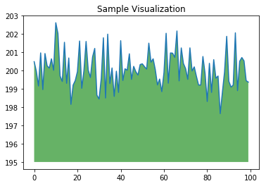

```python
import numpy as np
from matplotlib import pyplot as plt

ys = 200 + np.random.randn(100)
x = [x for x in range(len(ys))]

plt.plot(x, ys, '-')
plt.fill_between(x, ys, 195, where=(ys > 195), facecolor='g', alpha=0.6)

plt.title("Sample Visualization")
plt.show()
```

You can import your own data into Colab notebooks from your Google Drive account, including from spreadsheets, as well as from Github and many other sources. To learn more about importing data, and how Colab can be used for data science, see the links below under Working with Data.

## Machine learning

With Colab you can import an image dataset, train an image classifier on it, and evaluate the model, all in just [a few lines of code](https://colab.research.google.com/github/tensorflow/docs/blob/master/site/en/tutorials/quickstart/beginner.ipynb). Colab notebooks execute code on Google's cloud servers, meaning you can leverage the power of Google hardware, including GPUs and TPUs, regardless of the power of your machine. All you need is a browser.

Colab is used extensively in the machine learning community with applications including:

- Getting started with TensorFlow
- Developing and training neural networks
- Experimenting with TPUs
- Disseminating AI research
- Creating tutorials

To see sample Colab notebooks that demonstrate machine learning applications, see the machine learning examples below.

## More Resources

### Working with Notebooks in Colab

- Overview of Colaboratory
- Guide to Markdown
- Importing libraries and installing dependencies
- [Saving and loading notebooks in GitHub](https://colab.research.google.com/github/googlecolab/colabtools/blob/master/notebooks/colab-github-demo.ipynb)
- Interactive forms
- Interactive widgets
- TensorFlow 2 in Colab

### Working with Data

- Loading data: Drive, Sheets, and Google Cloud Storage
- Charts: visualizing data
- Getting started with BigQuery

### Machine Learning Crash Course

These are a few of the notebooks from Google's online Machine Learning course. See the [full course website](https://developers.google.com/machine-learning/crash-course/) for more.

- Intro to Pandas
- Tensorflow concepts

### Using Accelerated Hardware

- TensorFlow with GPUs
- TensorFlow with TPUs

## Machine Learning Examples

To see end-to-end examples of the interactive machine learning analyses that Colaboratory makes possible, check out these tutorials using models from [TensorFlow Hub](https://tfhub.dev).

A few featured examples:

- [Retraining an Image Classifier](https://tensorflow.org/hub/tutorials/tf2_image_retraining): Build a Keras model on top of a pre-trained image classifier to distinguish flowers.
- [Text Classification](https://tensorflow.org/hub/tutorials/tf2_text_classification): Classify IMDB movie reviews as either *positive* or *negative*.
- [Style Transfer](https://tensorflow.org/hub/tutorials/tf2_arbitrary_image_stylization): Use deep learning to transfer style between images.
- [Multilingual Universal Sentence Encoder Q&A](https://tensorflow.org/hub/tutorials/retrieval_with_tf_hub_universal_encoder_qa): Use a machine learning model to answer questions from the SQuAD dataset.
- [Video Interpolation](https://tensorflow.org/hub/tutorials/tweening_conv3d): Predict what happened in a video between the first and the last frame.